# ps2

Boyu Chen

2023-04-24

# Question 1

```r
source("ps2_q1_fn.R")
```

In `ps2_q1_fn.R`, I write some functions to help my analysis, I will show them in the appendix.

## read data

```r
data <- readxl::read_xlsx("CilibertoTamerEconometrica.xlsx")
data <- cbind(data[ ,1:7], rowSums(data %>% select(2:7)), data[ ,8:27])
names(data)[8] <- 'total.N'
n.mkt <- dim(data)[1] #the number of rows of the data set
true.n <- data[,2:8]
get_XX_and_Z.mat_and_Y()
```

After reading the data, I aggregated the presence of each firms, and called it `total.N`. Then we select the second to eighth columns of the data, called it `true.n` And I write a function `get_XX_and_Z.mat_and_Y()`, it is nothing but just for saving space and generate `XX`, `Z_mat` and `Y`. Where `XX` is an `n.mkt`x3 matrix, `Z_mat` is a `n.mkt`x12 matrix, `Y` is a `n.mkt`x1 vector.
$$XX = [1 \space\space marketdistance \space\space marketsize]\\
Z = [Z1 \space Z2 \space Z3 \space Z4 \space Z5 \space Z6]\\
Y = (total.N_1, total.N_2, ...,total.N_{n.mkt})$$
In `XX`, we have 2742 rows, each row recorded the “constant term”, “market distance” and “market size” for market i , i =1,…, 2742 In `Z`, we have 2742 rows, for each row we have [z1, …, z6] and z1 has 2 elements, one is “market presence” and the other is “min distance from hub” for firm 1. Similarly, z2,…,z6 have also 2 elements and stand for the same meaning. In `Y`, we have 2742 rows, and each row recorded the total number of the firms entered the market.

## ordered probit

```r
like_oprobit<- function(init){
    beta.mat <- init[1:3]
    delta <- init[4]
    f <- 0
    for (i in 1:n.mkt){
        if (Y[i] == 0){
            p = pnorm(-t(XX[i,])%*% beta.mat)
        }
        else if (Y[i] == 6){
            p = 1 - pnorm(-t(XX[i,]) %*% beta.mat + delta*log(Y[i]))
        }
        else{
            p = pnorm(-t(XX[i,]) %*% beta.mat + delta*log(Y[i]+1)) - pnorm(-t(XX[i,]) %*% beta.mat + delta*log(Y[i]))
        }
    }
    f <- f -log(p)
}
```

The ordered probit model is
$$\pi_{i}(N) = X_i\beta + \delta ln(N) + u_{i0}$$
Where $X_i$ is the market characteristics and $N$ is the potential number of entered firms in the market. Let $N_i^*$ denote the actual number of entered firms, we can inference the profitability of each firm by calculate the conditional probability given $N_i$. For the case $N_i = 0$, we can infer that no any potential firm can earn money in the market $i$. Thus, the probability of $N_i^* = 0$ is
$$P(N_i^* = 0) = P(\pi_i(1) \leq 0) = P(X_i\beta - \delta ln(1) + u_{i0}
\leq 0 ) = \Phi(-X_i\beta)$$
For the case $N_i = 6$, we can infer that all firms can earn money in the market $i$. Thus, the probability of $N_i^* = 6$ is
$$P(N_i^* = 6) = P(\pi_i(6) \geq 0) = 1-P(\pi_i(6) \leq 0) = 1-
\Phi(-X_i\beta+\delta ln(6))$$
For the rest of cases, $N_i = 1, 2, ..., 5$, the probability is
$$P(N_i^* = N_i) = \Phi(-X_i\beta+\delta ln(N_i+1)) -
\Phi(-X_i\beta+\delta ln(N_i))$$

```r
set.seed(1234)
init <- c(1,1,1,1)
fit <- optim(fn = like_oprobit, par = init, method = "BFGS")
```

```r
par_df <- data.frame(value = fit[["par"]])
rownames(par_df) <- c("b0", "b1", "b2", "d")
kable(par_df)
```

|  | value |
| --- | --- |
| b0 | 1.648658 |
| b1 | 1.587684 |
| b2 | 1.561012 |
| d | 12.974703 |

## MSM

```r
T <- 10
set.seed(2048)
init.param = c(1, 1, 1.5, -1, 2, 2.5, 1.5)
msm.fit <- optim(fn = obj.fn, par = init.param, method = "BFGS")
```

```r
par_df <- data.frame(value = msm.fit[["par"]])
rownames(par_df) <- c("a1", "a2", "b0", "b1", "b2", "d", "rho")
kable(par_df)
```

|  | value |
| --- | --- |
| a1 | -5.931502 |
| a2 | -6.947449 |
| b0 | 1.260920 |
| b1 | -33.029460 |
| b2 | -7.752644 |
| d | 3.406475 |
| rho | -14.016409 |

# Question 2

### DGP

```r
# DGP
set.seed(123)
x <- c(rnorm(3000, 20, 5), rnorm(2000, 10, 3))
df <- data.frame(x = x)
```

### Plot histogram

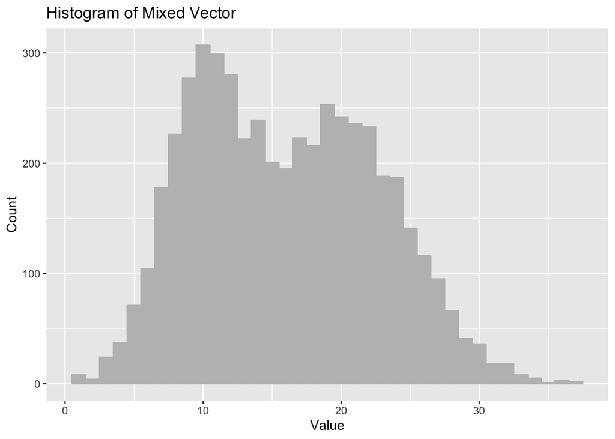

```r
ggplot(df, aes(x = x)) +
    geom_histogram(binwidth = 1, color = "gray", fill = "gray") +
    labs(title = "Histogram of Mixed Vector",
         x = "Value",
         y = "Count")
```

### init param

```r
mu <- c(8, 15)
sigma <- c(5, 5)
pi <- c(0.5, 0.5)
```

### functions

```r
# E-step
estep <- function(x, mu, sigma, pi) {
    n <- length(x)
    k <- length(mu)
    post <- matrix(0, n, k)
    for (i in 1:n) {
        for (j in 1:k) {
            post[i, j] <- dnorm(x[i], mu[j], sigma[j]) * pi[j]
        }
        post[i, ] <- post[i, ] / sum(post[i, ])
    }
    return(post)
}

# M-step
mstep <- function(x, post) {
    n <- nrow(post)
    k <- ncol(post)
    mu <- numeric(k)
    sigma <- numeric(k)
    pi <- numeric(k)
    for (j in 1:k) {
        mu[j] <- sum(post[, j] * x) / sum(post[, j])
        sigma[j] <- sqrt(sum(post[, j] * (x - mu[j])^2) / sum(post[, j]))
        pi[j] <- sum(post[, j]) / n
    }
    return(list(mu = mu, sigma = sigma, pi = pi))
}

# EM
em <- function(x, mu, sigma, pi, tol = 1e-6, maxiter = 100) {
    loglik <- numeric(maxiter)
    for (iter in 1:maxiter) {
        # E-step
        post <- estep(x, mu, sigma, pi)
        # M-step
        params <- mstep(x, post)
        # update parameters
        mu <- params$mu
        sigma <- params$sigma
        pi <- params$pi
        # calculate log-likelihood
        loglik[iter] <- sum(post[,1]* log(pi[1]) + dnorm(x, mu[1], sigma[1], log=TRUE)+
                                post[,2]* log(pi[2]) + dnorm(x, mu[2], sigma[2], log=TRUE))
        # check convergence
        if (iter > 1 && abs(loglik[iter] - loglik[iter - 1]) < tol) {
            break
        }
    }
    return(list(mu = mu, sigma = sigma, pi = pi, loglik = loglik[1:iter]))
}
```

### EM Result Table

```r
result <- em(x, mu, sigma, pi)
res_df <- data.frame(mu = result$mu, sigma = result$sigma, pi = result$pi)
rownames(res_df) <- c('x1', 'x2')
kable(res_df)
```

|  | mu | sigma | pi |
| --- | --- | --- | --- |
| x1 | 9.927575 | 2.960945 | 0.3983197 |
| x2 | 20.042762 | 4.986873 | 0.6016803 |

### EM Result Histogram

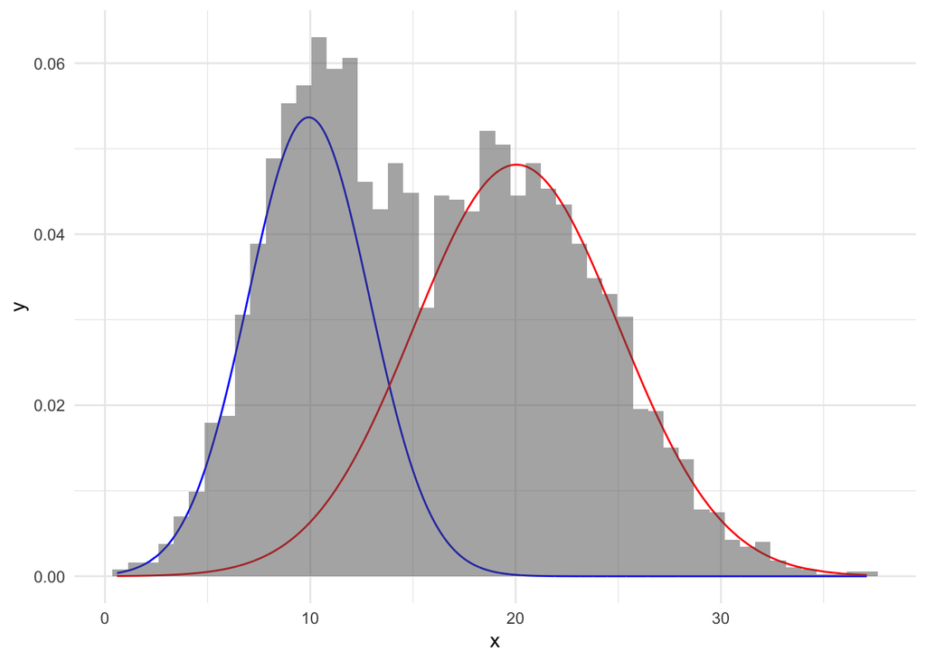

```r
df$y <- result$pi[1]*dnorm(df$x, mean = result$mu[1], sd = result$sigma[1])
df$z <- result$pi[2]*dnorm(df$x, mean = result$mu[2], sd = result$sigma[2])

ggplot(df, aes(x = x)) +
    geom_line(aes(y = y), color = "blue") +
    geom_line(aes(y = z), color = "red") +
    geom_histogram(aes(y = after_stat(density)), bins = 50, alpha = 0.5) +
    theme_minimal()
```

# Appendix: Functions for Question 1

```r
get_XX_and_Z.mat_and_Y <- function(...){
    X1 <- data$marketdistance
    X2 <- data$marketsize
    XX <<- cbind(rep(1, n.mkt), X1, X2)

    Z1 <<- cbind(data[ ,17], data[,23])
    Z2 <<- cbind(data[ ,18], data[,24])
    Z3 <<- cbind(data[ ,19], data[,25])
    Z4 <<- cbind(data[ ,20], data[,26])
    Z5 <<- cbind(data[ ,21], data[,27])
    Z6 <<- cbind(data[ ,22], data[,28])
    Z.mat <<- cbind(Z1, Z2, Z3, Z4, Z5, Z6)

    Y <<- data$total.N
}

draw_u <- function(...){
    u_ik <<- matrix(rnorm(n.mkt * 6), ncol=6)
    u_i0 <<- rnorm(n.mkt)
}



like_oprobit<- function(init){
    beta.mat <- init[1:3]
    delta <- init[4]
    f <- 0
    for (i in 1:n.mkt){
        if (Y[i] == 0){
            p = pnorm(-t(XX[i,])%*% beta.mat)
        }
        else if (Y[i] == 6){
            p = 1 - pnorm(-t(XX[i,]) %*% beta.mat + delta*log(Y[i]))
        }
        else{
            p = pnorm(-t(XX[i,]) %*% beta.mat + delta*log(Y[i]+1)) - pnorm(-t(XX[i,]) %*% beta.mat + delta*log(Y[i]))
        }
    }
    f <- f -log(p)
}



single.sim.process <- function(A, B, d, rho){
    n_pred <- matrix(nrow=n.mkt, ncol=7)
    for (mkt.i in 1:n.mkt){ # 1:n.mkt
        is.in <- 0
        Z <- Z.mat[mkt.i, ] %>% matrix(ncol = 2, byrow = TRUE)
        rho <- 1 / (1 + exp(-rho)) # keep rho between 0 and 1

        for (n.try in 0:6){
            profit <- Z %*% A + sqrt(1-rho^2) * u_ik[mkt.i, ] + as.numeric(XX[mkt.i, ] %*% B) + rho * u_i0[mkt.i] - log(n.try)*d

            total.in <- sum(profit > 0)

            if (total.in < n.try){
                n_pred[mkt.i, 7] <- n.try - 1
                n_pred[mkt.i, 1:6] <- is.in
                break
            }
            is.in <- as.numeric(profit > 0)
            if (total.in == 6 & n.try == 6){
                n_pred[mkt.i, 7] <- n.try
                n_pred[mkt.i, 1:6] <- is.in
            }
        }

    }
    return(n_pred)
}

get.n_hat <- function(A,B,d,rho){
    container <- matrix(0, nrow=n.mkt, ncol=7)
    for (t in 1:T){
        draw_u()
        container <- container + single.sim.process(A,B,d,rho)
    }
    n_hat<- container / T
    return(n_hat)
}

pred.error <- function(n_hat){
    v <- true.n - n_hat
    return(v)
}

g_n.fn <- function(v){
    v <- as.matrix(v)
    E_v0X  = v[,7] * XX
    E_v1Z  = v[,1] * Z1
    E_v2Z  = v[,2] * Z2
    E_v3Z  = v[,3] * Z3
    E_v4Z  = v[,4] * Z4
    E_v5Z  = v[,5] * Z5
    E_v6Z  = v[,6] * Z6

    v_i_hat <- cbind(E_v0X, E_v1Z, E_v2Z, E_v3Z, E_v4Z, E_v5Z, E_v6Z)
    g_n <- colMeans(v_i_hat)
    return(g_n)
}

obj.fn <- function(para){
    A <- para[1:2]
    B <- para[3:5]
    d <- para[6]
    rho <- para[7]
    n_hat <- get.n_hat(A,B,d,rho)
    v <- pred.error(n_hat)
    g_n <- g_n.fn(v)
    mom <- t(g_n) %*% g_n
    return(mom)
}
```